# Practical Machine Learning Project

Ayushmaan

11/08/2020

# Project Overview

## Introduction

This project is the final course project for the Practical Machine Learning Coursera Course by Johns Hopkins University. In this report, we will build a machine learning algorithm to predict the manner in which some participants did an exercise. Further, we will use it to predict on 20 different test cases.

## Background and Data

Using devices such as Jawbone Up, Nike FuelBand, and Fitbit it is now possible to collect a large amount of data about personal activity relatively inexpensively. These type of devices are part of the quantified self movement – a group of enthusiasts who take measurements about themselves regularly to improve their health, to find patterns in their behavior, or because they are tech geeks. One thing that people regularly do is quantify how much of a particular activity they do, but they rarely quantify how well they do it. In this project, your goal will be to use data from accelerometers on the belt, forearm, arm, and dumbell of 6 participants. They were asked to perform barbell lifts correctly and incorrectly in 5 different ways. The data was sourced from the website here: http://web.archive.org/web/20161224072740/http:/groupware.les.inf.puc-rio.br/har

# Loading Required Libraries and adding Reproducibilty

```r
library(dplyr)
```

```r
library(rpart)
library(rpart.plot)
library(rattle)
library(caret)
library(randomForest)
library(corrplot)
library(gbm)
library(RColorBrewer)

set.seed(1234)
```

# Initialising Data

## Loading Data

```r
training <- read.csv(url("https://d396qusza40orc.cloudfront.net/predmachlearn/pml-training.csv"),header=TRUE)
dim(training)
```

```
## [1] 19622   160
```

```r
testing <- read.csv(url("https://d396qusza40orc.cloudfront.net/predmachlearn/pml-testing.csv"), header = TRUE)
dim(testing)
```

```
## [1]  20 160
```

```r
str(training)
```

```
## 'data.frame':    19622 obs. of  160 variables:
##  $ X                       : int  1 2 3 4 5 6 7 8 9 10 ...
##  $ user_name               : chr  "carlitos" "carlitos" "carlitos" "carlitos" ...
##  $ raw_timestamp_part_1    : int  1323084231 1323084231 1323084231 1323084232 1323084232 1323084232 1323084232 1323084232 1323084232 1323084232 ...
##  $ raw_timestamp_part_2    : int  788290 808298 820366 120339 196328 304277 368296 440390 484323 484434 ...
##  $ cvtd_timestamp          : chr  "05/12/2011 11:23" "05/12/2011 11:23" "05/12/2011 11:23" "05/12/2011 11:23" ...
##  $ new_window              : chr  "no" "no" "no" "no" ...
##  $ num_window              : int  11 11 11 12 12 12 12 12 12 12 ...
##  $ roll_belt               : num  1.41 1.41 1.42 1.48 1.48 1.45 1.42 1.42 1.43 1.45 ...
##  $ pitch_belt              : num  8.07 8.07 8.07 8.05 8.07 8.06 8.09 8.13 8.16 8.17 ...
##  $ yaw_belt                : num  -94.4 -94.4 -94.4 -94.4 -94.4 -94.4 -94.4 -94.4 -94.4 -94.4 ...
##  $ total_accel_belt        : int  3 3 3 3 3 3 3 3 3 3 ...
##  $ kurtosis_roll_belt      : chr  "" "" "" "" ...
##  $ kurtosis_picth_belt     : chr  "" "" "" "" ...
##  $ kurtosis_yaw_belt       : chr  "" "" "" "" ...
```

[output cut: 86 more lines]

```r
str(testing)
```

```
## 'data.frame':    20 obs. of  160 variables:
##  $ X                       : int  1 2 3 4 5 6 7 8 9 10 ...
##  $ user_name               : chr  "pedro" "jeremy" "jeremy" "adelmo" ...
##  $ raw_timestamp_part_1    : int  1323095002 1322673067 1322673075 1322832789 1322489635 1322673149 1322673128 1322673076 1323084240 1322837822 ...
##  $ raw_timestamp_part_2    : int  868349 778725 342967 560311 814776 510661 766645 54671 916313 384285 ...
##  $ cvtd_timestamp          : chr  "05/12/2011 14:23" "30/11/2011 17:11" "30/11/2011 17:11" "02/12/2011 13:33" ...
##  $ new_window              : chr  "no" "no" "no" "no" ...
##  $ num_window              : int  74 431 439 194 235 504 485 440 323 664 ...
##  $ roll_belt               : num  123 1.02 0.87 125 1.35 -5.92 1.2 0.43 0.93 114 ...
##  $ pitch_belt              : num  27 4.87 1.82 -41.6 3.33 1.59 4.44 4.15 6.72 22.4 ...
##  $ yaw_belt                : num  -4.75 -88.9 -88.5 162 -88.6 -87.7 -87.3 -88.5 -93.7 -13.1 ...
##  $ total_accel_belt        : int  20 4 5 17 3 4 4 4 4 18 ...
##  $ kurtosis_roll_belt      : logi  NA NA NA NA NA NA ...
##  $ kurtosis_picth_belt     : logi  NA NA NA NA NA NA ...
##  $ kurtosis_yaw_belt       : logi  NA NA NA NA NA NA ...
```

[output cut: 86 more lines]

From seeing the structure of the training and testing dataset, it is quite clear that there are several columns which have missing values either present as NA or empty values (""). We can clean the datasets by removing such columns and also those columns which contain names, timestamps etc. that won;t affect the prediction model.

## Data Cleaning

### Based on NA/Missing Values

```r
i1 <- 1
emptycol1 <- c(0)
for(col1 in names(training)){
        count1 = sum(ifelse(training[,col1] == ""|is.na(training[, col1]), 1, 0))
       emptycol1[i1] <- ifelse(count1 == 0, 1, 0)
       i1 <- i1 + 1
}

i2 <- 1
emptycol2 <- c(0)
for(col2 in names(testing)){
  count2  = sum(ifelse(testing[, col2]==""|is.na(testing[, col2]), 1, 0))
  emptycol2[i2] <- ifelse(count2==0, 1, 0)
  i2 <- i2 +1
}
rm(i1, i2, col1, col2, count1, count2)
```

The above code chunk sorts out those columns which have NA/missing values (coded as 0), and those that don’t have (coded as 1), for both our training and testing datasets. The follwing code chunk sorts out the cleaned datasets we would be using for our modelling and prediction.

```r
training_clean <- training[, as.logical(emptycol1)]
training_clean <- training_clean[, -c(1:7)]
dim(training_clean)
```

```
## [1] 19622    53
```

```r
testing_clean <- testing[, as.logical(emptycol2)]
testing_clean <- testing_clean[, -c(1:7)]
dim(testing_clean)
```

```
## [1] 20 53
```

```r
rm(emptycol1, emptycol2)
```

### Based on Zero/Near-Zero-Variance features

```r
any(nearZeroVar(training_clean, saveMetrics = T)[, c("zeroVar", "nzv")]==TRUE)
```

```
## [1] FALSE
```

As we can see, there are no zero/near zero variance features in our training set.

## Partitioning Data for Model Buiding

```r
set.seed(1234)

inTrain <- createDataPartition(training_clean$classe, p = 0.6, list = F)
train_data <- training_clean[inTrain, ]
validation_data <- training_clean[-inTrain, ]

dim(train_data)
```

```
## [1] 11776    53
```

```r
dim(validation_data)
```

```
## [1] 7846   53
```

The testing set remains untouched as the final model will be applied on it, so that the model selection remains unbiased and not overfitted.

# Constructing and Improving Model

## Exploratory Data Analysis

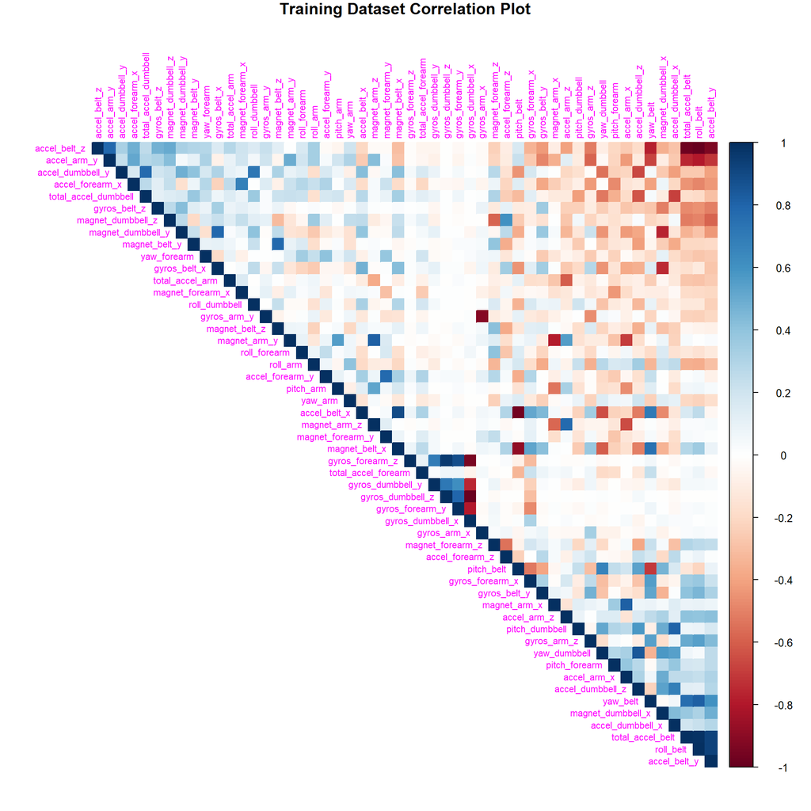

```r
corrplot(cor(train_data[, -53]), order = "FPC", method = "color", type = "upper", tl.cex = 0.7, tl.col = rgb(1, 0, 1),mar = c(0, 0, 1, 0), title = "Training Dataset Correlation Plot")
```

```r
corrmatrix <- abs(cor(train_data[,-53]))
diag(corrmatrix) <- 0
corrmatrix <- which(corrmatrix > 0.9, arr.ind = T)
corrmatrix <- dim(corrmatrix)[1]
corrmatrix
```

```
## [1] 22
```

## Building the Model

For our project, we will use the Random Forest model with cross-validation to build our prediction model.

### Cross-Validation

In order to limit the effects of overfitting, and improve the efficicency of the models, we will use the cross-validation technique. Cross-validation is done for each model with number of folds = 10. This is set in the below code chunk using the fitControl object as defined below, and then the random forest model is trained with cross-validation.

```r
fitControl <- trainControl(method = "cv", number = 10, classProbs = T )
model <- train(classe ~., data = train_data, method = "rf", trControl = fitControl, verbose = F)
```

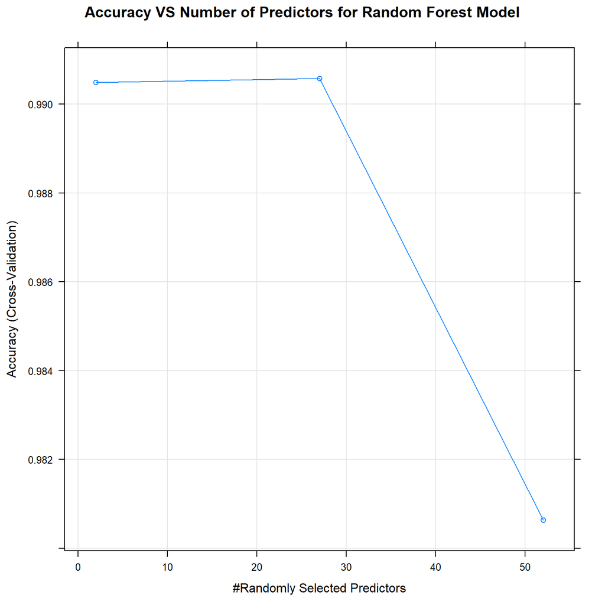

```r
plot(model, main = "Accuracy VS Number of Predictors for Random Forest Model")
```

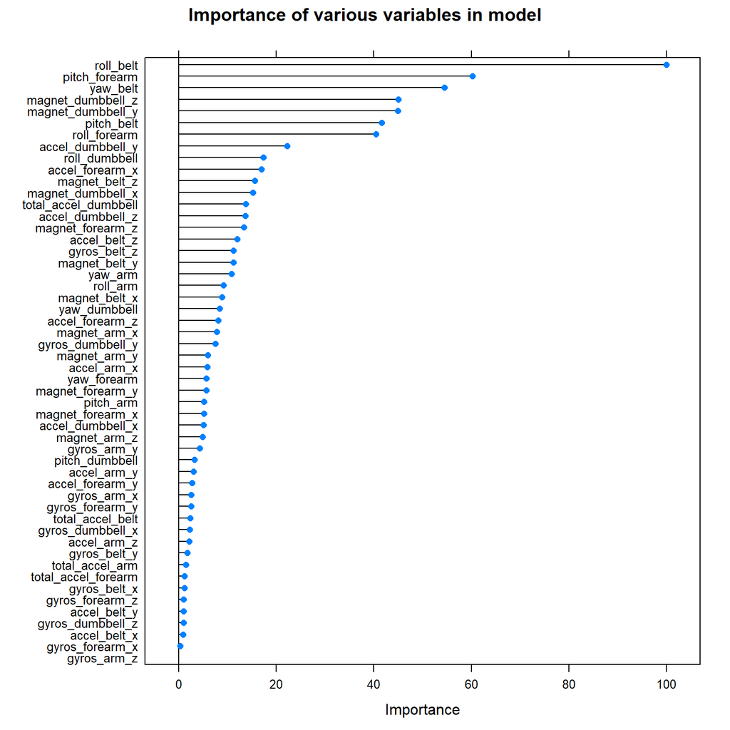

```r
plot(varImp(model), main = "Importance of various variables in model")
```

### Prediction

```r
model_predict <- predict(model,newdata=validation_data)
caret::confusionMatrix(as.factor(validation_data$classe), model_predict)
```

```
## Confusion Matrix and Statistics
##
##           Reference
## Prediction    A    B    C    D    E
##          A 2231    0    1    0    0
##          B    9 1507    1    1    0
##          C    0   10 1347   11    0
##          D    0    0   11 1273    2
##          E    0    1    4    6 1431
##
## Overall Statistics
##
##                Accuracy : 0.9927
##                  95% CI : (0.9906, 0.9945)
##     No Information Rate : 0.2855
##     P-Value [Acc > NIR] : < 2.2e-16
##
##                   Kappa : 0.9908
##
##  Mcnemar's Test P-Value : NA
##
## Statistics by Class:
##
##                      Class: A Class: B Class: C Class: D Class: E
## Sensitivity            0.9960   0.9928   0.9875   0.9861   0.9986
## Specificity            0.9998   0.9983   0.9968   0.9980   0.9983
## Pos Pred Value         0.9996   0.9928   0.9846   0.9899   0.9924
## Neg Pred Value         0.9984   0.9983   0.9974   0.9973   0.9997
## Prevalence             0.2855   0.1935   0.1738   0.1645   0.1826
## Detection Rate         0.2843   0.1921   0.1717   0.1622   0.1824
## Detection Prevalence   0.2845   0.1935   0.1744   0.1639   0.1838
## Balanced Accuracy      0.9979   0.9955   0.9921   0.9920   0.9984
```

```r
print(model)
```

```
## Random Forest
##
## 11776 samples
##    52 predictor
##     5 classes: 'A', 'B', 'C', 'D', 'E'
##
## No pre-processing
## Resampling: Cross-Validated (10 fold)
## Summary of sample sizes: 10597, 10599, 10597, 10599, 10600, 10597, ...
## Resampling results across tuning parameters:
##
##   mtry  Accuracy   Kappa
##    2    0.9904896  0.9879688
##   27    0.9905747  0.9880769
##   52    0.9806397  0.9755096
##
## Accuracy was used to select the optimal model using the largest value.
## The final value used for the model was mtry = 27.
```

```r
print(model$finalModel)
```

```
##
## Call:
##  randomForest(x = x, y = y, mtry = param$mtry, verbose = ..1)
##                Type of random forest: classification
##                      Number of trees: 500
## No. of variables tried at each split: 27
##
##         OOB estimate of  error rate: 0.99%
## Confusion matrix:
##      A    B    C    D    E class.error
## A 3338    5    3    0    2 0.002986858
## B   20 2245   12    2    0 0.014918824
## C    0   16 2027   11    0 0.013145083
## D    1    3   26 1898    2 0.016580311
## E    0    0    4    9 2152 0.006004619
```

# Applying Model on Testing set